# Phenotypic Data Review in R Markdown

Martha Richards

This document details and explains the work completed in the first term of my placement year in the Psychosis Group at Cardiff University. This work outlines how to create a R Markdown file to display the phenotypic data from the Programme Grant, and covers the skills I have learnt, experience in the R language, the tools I have used as well as broader research.

## **Project Review**

### What is a Phenotypic Data Review?

Phenotypic data is a principal component to genetic studies, comprising of the observable characteristics or traits the participants in the study exhibit. The project I am working on – Programme Grant – uses phenotypic reviews to examine, document and visualise variables selected by the principal investigators. The main goal of the review is to understand what data is available and how it can be used for downstream analyses. Each variable is visualised to show its distribution, which helps identify data quality issues such as outliers, unexpected values, or high rates of missing data before any formal analysis begins.

A key challenge is, datasets come from a mixture of in-house studies and external sources, meaning they were collected at different times, by different teams, and using different methods or coding systems. The review therefore documents each variable in detail, including its data type, how missing values are recorded, and any unusual or abnormal values, so that these differences are transparent and understood. The value of this is all the data can be displayed and understood in a uniform way.

Ultimately the phenotypic data review serves as a reference point for researchers working on the project in the future. By clearly documenting which variables exist across datasets and how they are coded, it makes it possible to identify which variables can be harmonised enabling larger and more powerful analyses.

### Research Outcomes

The four outcomes chosen by the team are:

#### Psychiatric Hospital Admissions

These measures the severity and course of illness. This outcome is helpful because it as objective marker which can be easily compared across groups and can be attainable through health records.

#### Relationships

Relationships are studied because psychosis often emerges in late adolescence/early adulthood, a critical time for forming complex social bonds. Symptoms like paranoia, social withdrawal, and disorganised thinking directly damage a person’s ability to maintain friendships and romantic relationships. Poor relationships also worsen prognosis.

#### Social-Occupational Functioning

This captures the participants using a more holistic approach and how their illness affects them in their day-to-day life. Social-occupational functioning can also show whether treatment is having a broader effect on their normal lives not just reducing symptoms.

#### Treatment Response

This outcome is important because psychosis is highly heterogeneous - while some people respond well to treatment others may not respond at all. Understanding what predicts good or poor treatment response helps clinicians personalise care and researchers identify biological sub-types of the illness.

### Outcomes vs Covariates

Before plotting variables, I had to learn how to sort them into either covariates or outcomes. Outcomes are the primary variables of interest that we aim to explain or predict. For example, one aim is to show how genetics can explain why certain people have a certain treatment response. While covariates are additional variables which may influence the outcome and need to be accounted for in analyses.

## **R Markdown**

### What is an R Markdown?

R Markdown is a file format used in R that combines written text, code, and output all in one document. Unlike a standard R script which only contains code, an R Markdown file allows you to weave together explanations, analysis, and results into a single, readable document. During the first semester I made six of these documents to contribute to the grant.

### Key Features Used

#### Knit

When the R markdown file is run, using the “knit” button it is rendered into a HTML file which can be viewed online, by anyone who it is shared with. The output of the knit button is a html link which is saved to the files in your computer.

#### Code Chunks

R markdown files also use “chunks” which are sections of the document which contain code. This is useful to show the code which can be used to show collaborators what has been done with the data. These chunks can be hidden or shown depending on which code you want to be shared.

#### Chunk Options

On the Markdown file you can choose how or if you want your code to be displayed. In the top line of the chunk, you can add different codes to choose how you want the chunk you have use to be displayed. This is useful to show collaborators how the data has been used. Some examples of chunk options are:

- echo = TRUE – displays the code in the Markdown fil
- eval = TRUE – run the code in chunk
- include = TRUE – include the chunk in the Markdown file after running
- warning = TRUE – display the warning codes in the document.

#### Tabbed Sections

R markdown files are also useful because you can use tabs to show specific data, for example only the outcomes you want to be investigated. This is helpful because rather than producing one long document, where you must scroll for navigation, you have buttons which select for what you want. The code for this is {.tabset} after the title you want to be tabbed

## **File Management and Documentation Standards**

In bioinformatics, good file management and organisation is vital reproducibility, usability and validity. Naming files correctly with consistent conventions enables scientists to track what each file contains and how it has been used. Furthermore, lots of bioinformatics research needs to be reproducible to explain to other researchers how the analysis was done. If files are named ambiguously or stored inconsistently, even the original researcher may struggle to recreate their own analysis months later, let alone a collaborator or reviewer.

### Variable Description Format

Cardiff University follows a specific format for documenting each variable in a phenotypic review. The structure allows anyone reading the review can understand all data processing decisions and replicate the work accurately.

Here is the format

**Variable Name**

This is a [numeric/character/date] sting. This captures [description of what the variable entails].

There are [/not] NAs in this variable.

For plotting the NAs have been converted to [-9/2030] **OR** For plotting the NAs were kept as they were.

*If there is encoding in the code book, follow this format.*

The encoding is as follows:

- 0 = No
- 1 = Yes

_If there is data which is not encoded for, explain why in the description__

*If variable is a text string variable, write this phrase*

“This is a text string variable and was not plotted on this document. This variable captures….”

## **Data**

### **Data Import and Inspection**

#### Importing Different File Formats

Phenotypic datasets arrive in various formats, so I have become proficient in reading different file types into R. The main functions used have been read.csv() for comma-separated files, read_excel() for Excel spreadsheets, and various readr functions for other text-based formats. Each function has slightly different default behaviours, so understanding their differences is important for importing data correctly.

#### Inspecting Data After Import

Once the data has been imported and set as “df” for dataframe on R, I learnt to inspect the data to check the structure of the variable. For example, if the variable is in a numeric, date or character string format, or whether there are NAs (values with no input). The common codes I used to inspect the code were summary() which loads a statistical overview of the data, which can show the mean if the value is numeric or show ‘character’ if the variable is in a text string. This preliminary check helps to choose which graph to plot, as well as how to account for NA values.

### Understanding Libraries and Packages

A library in R is a collection of pre-written code that extends what R can do beyond its basic built-in functions. Libraries (packages) are created by developers and researchers around the world and shared freely, meaning you do not have to write complex code from scratch for common tasks. In the documents I made, common libraries used were ‘ggplot2’ to visualise the data and ‘dplyr’ for data manipulation. Sometimes you must install the package first using the code:

```r
install.packages()
```

To load the package in the file you then need to name it using:

```r
library()
```

### **Data Types and Missing Values**

#### Understanding Data Types

Phenotypic data can be numeric data like ages or dosages of medications or a character (text) like the answer to a survey e.g. medication name. It is important to know the difference between these types to choose the correct plot to use and how to correctly include and plot the NAs. Once the data is imported and inspected you can change or double check the data is in the right format. Sometimes, the data might look like a number, but R might think that the number is a character string because of the way the value was inputted in the original file. This is shown by the number appearing in quote marks , “2”. So, at the start of each code chunk, you need to choose whether to convert all the data to as.character(), which converts data to text, or as.numeric(), which converts data to numbers. These functions have a profound effect on plots — for example, converting numeric data to character format treats numbers as categorical labels. This would cause the original continuous data to be displayed incorrectly.

#### Handling Missing Values (NAs)

One thing I underestimated when producing these reviews was the effect of missing data. Missing data (often coded for as NA) can distort results which can lead to false interpretations of the investigation. Sometimes R may exclude NA values from calculations but in this review, we wanted to see all the results. If NAs aren’t handled before plotting, they can cause errors or silently disappear from graphs, making distributions look cleaner than they are. In a phenotypic review, it’s important to document and show the extent of missing data so collaborators understand the true completeness of each variable. Plotting missing data is also important because statistical tests require complete data. If the participant or variable is indicated in the review to have missing data then it might be a good idea to exclude the variable or participant from the study, so results are not skewed. Also, different datasets often record missing values differently; some use blank cells, some use -9, some use a specific string like “N/A”. If these aren’t standardised, missingness can be misread as real data values, which can distort any analysis or attempt to combine datasets.

#### Quality Control and Validation

One of the skills I have practiced is checking that the data ranges in the variable makes sense for the plot created. This includes checking that data ranges are appropriate for each variable, identifying outliers that might indicate data entry errors, and using frequency tables (via table() or count()) to check the distribution of categorical variables. Furthermore, using unique() to see all the separate values which have been included. This line often shows what kind of missing data is included and how the data might have changed with the coding you have already done.

## **Data Visualisation with ggplot2**

### What is ggplot2?

ggplot2 is an R package used to create plots to visualise data. The code works by building on a basic line layer by layer, to make the plot more complex yet also easier to read.

### Plot Types Used

The most common plot types I have created during the review are bar charts for because they can show the count number for each value. However for values which included decimal points, a histogram was used because of the different number formatting. The choice of plot type depends on the data type of the variable being visualised, which is another reason why correctly setting data types before plotting is essential.

#### Key Techniques

I learnt how to add different code lines to enhanced the basic ggplot2 graph. This can show additional data and makes the plots clearer and more informative.

##### Fill Aesthetic

In the Grant, all values were plotted by their variables but also by Sex, to show the difference between the two. So, this would show the values with two columns each one Male and one Female. This allows you to add an additional dimensions to the plot and show subgroups.

##### Titles and Labels

Adding clear titles and axis labels using labs() ensures that plots are self-explanatory and professional. This is important for a review document that may be read by collaborators unfamiliar with the raw variable names.

##### Saving Plots

I learned how to use ggsave() to export the plots and save them to the OneDrive, This enables the plot to be used outside of the Markdown file and double saving the plot itself, while the code is saved on R. This also allows plots to be saved in the correct format with the correct dimensions. These saved plots are then imported onto the Markdown file themselves using the code

```r
![caption for the image](/path/to/image.png).]
```

## **Code Examples**

### Numeric Code for Plotting

```r
df$variable  <- as.character(df$variable) # This pulls all the data from that original data set into the code
df$variable  [df$variable  == 'NA'] <- "-9"
df$variable  [is.na(df$variable  )] <- "-9" # These two lines of code change all the NAs into "-9" for ease of plotting. This is because you cannot plot NA in a numeric plot, where would the NA go on the number line?
df$variable  <- as.numeric(df$variable  ) # This makes sure the values in the data sets are all recognised by R as a numeric string, from "2" to 2.
ggplot(df, aes(x = variable, fill = Sex)) + # This opens the plot from the ggplot2 packages. Begins a plot that you finish by adding layers to. Add one geom function per layer. You start by choosing the data set the variable is from, in this "df" means data frame. Next shows the aesthetic values, which in this case are the "variable" which is the variable you are choosing to analyses. Then fill(sex), separates the plot by the sex variable.
  geom_bar(position = "dodge", color = "white") + # geom_bar chooses the type of plot being used, this is where geom_histogram could also go. Position = "dodge" makes the "sex" columns appear next to each other instead of stacked, where male or female would be on top of each other. Color = "white" makes the boarders of the columns white.
  scale_fill_viridis_d(option = "turbo") + # This chooses a colour theme for the plot.
  labs(x = "variable", y = "Count") + # Adds the labels
  theme_minimal() # Chooses the plot theme itself
ggsave("variable.png") # Saves
```

### Character Code for Plotting

```r
df$variable  <- as.character(df$variable) # Pulls all the values from the data set.
df$variable  [df$variable  == 'NA'] <- "NA"
df$variable  [is.na(df$variable  )] <- "NA" # This pulls all of the NA values and plots them in the same format.
ggplot(df, aes(x = variable, fill = Sex)) +
  geom_bar(position = "dodge", color = "white") +
  scale_fill_viridis_d(option = "turbo") +
  labs(x = "variable", y = "Count") +
  theme_minimal()
ggsave("variable.png")
```

### Numeric Code for Plotting

```r
df$variable  <- as.character(df$variable)
df$variable  [df$variable  == 'NA'] <- "-9"
df$variable  [is.na(df$variable  )] <- "-9"
df$variable  <- as.numeric(df$variable)
ggplot(df, aes(x = variable, fill = Sex)) +
  geom_histogram(position = "dodge", color = "white") + # geom_histogram makes the plot a histogram.
  scale_fill_viridis_d(option = "turbo") +
  labs(x = "variable", y = "Count") +
  theme_minimal()
ggsave("variable.png")
```

## **Graph Examples**

### Character String

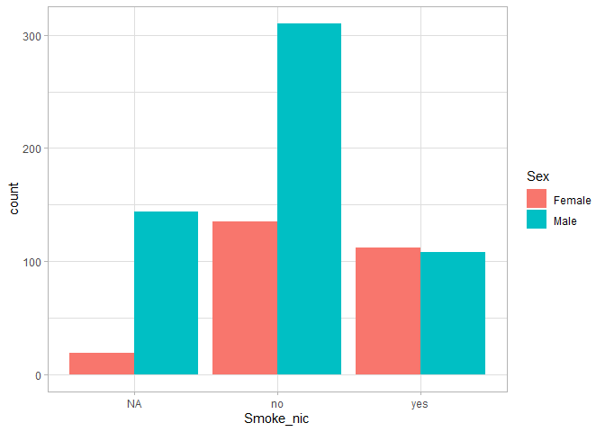

```r
df$Smoke_nic <- as.character(df$Smoke_nic)
df$Smoke_nic[is.na(df$Smoke_nic)] <- "NA"
df$Smoke_nic[df$Smoke_nic == "NA"] <- "NA"
ggplot(df, aes(x = Smoke_nic, fill = Sex)) +
    geom_bar(position = "dodge") +
    theme_light() +
    theme(axis.text.x = element_text(angle = 0)) +
    labs(x = "Smoke_nic")
```

```r
ggsave("Smoke_nic.png")
```

### Character String with encoding

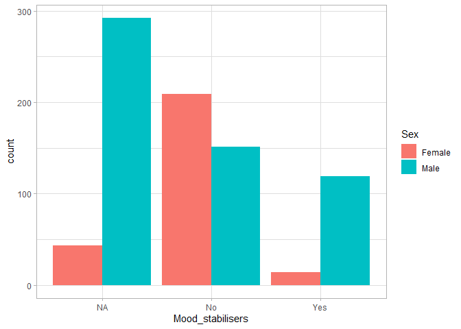

```r
df$Mood_stabilisers <- as.character(df$Mood_stabilisers)
df$Mood_stabilisers[is.na(df$Mood_stabilisers)] <- "NA"
df$Mood_stabilisers[df$Mood_stabilisers == "NA"] <- "NA"
df$Mood_stabilisers[df$Mood_stabilisers == "1"] <- "Yes"
df$Mood_stabilisers[df$Mood_stabilisers == "0"] <- "No"
ggplot(df, aes(x = Mood_stabilisers, fill = Sex)) +
    geom_bar(position = "dodge") +
    theme_light() +
    theme(axis.text.x = element_text(angle = 0)) +
    labs(x = "Mood_stabilisers")
```

```r
ggsave("Mood_stabilisers.png")
```

### Numeric String

Here the NA values have been converted into -9 to include all missing values on the plot.

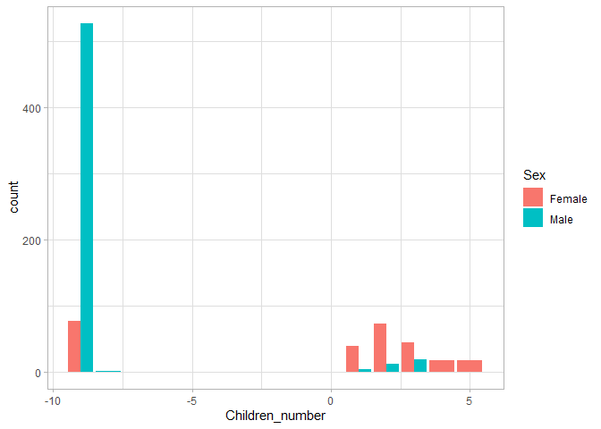

```r
df$Children_number <- as.character(df$Children_number)
df$Children_number[is.na(df$Children_number)] <- "-9"
df$Children_number[df$Children_number == "NA"] <- "-9"
df$Children_number[df$Children_number == "99"] <- "-8"

df$Children_number <- as.numeric(df$Children_number)
ggplot(df, aes(x = Children_number, fill = Sex)) +
    geom_bar(position = "dodge") +
    theme_light() +
    theme(axis.text.x = element_text(angle = 0)) +
    labs(x = "Children_number")
```

```r
ggsave("Children_number.png")
```